# Chromatin Segmentation with Hidden Markov Models

## Introduction

Chromatin segmentation tools like **ChromHMM** or **Segway** use HMMs to integrate multiple “tracks” of genomic data (like ChIP-seq for histone marks) and assign a hidden state (e.g., Promoter, Enhancer, or Repressed) to every position in the genome.

An HMM consists of:

1. **Hidden States ($S$):** The functional labels we want to discover.
2. **Transition Probabilities ($A$):** The probability of moving from one state to another (e.g., how likely is a Promoter to be followed by another Promoter?).
3. **Emission Probabilities ($B$):** The probability of seeing specific data values given a state (e.g., high H3K4me3 signal is very likely in a Promoter state).

## Step 1: Simulating Genomic Data

We will simulate 1,000 genomic “bins” and two tracks: **H3K4me3** (typically found at promoters) and **H3K27ac** (typically found at enhancers).

We define three hidden states: 1. **Background (State 1):** Low signal in both tracks. 2. **Promoter (State 2):** High H3K4me3, low H3K27ac. 3. **Enhancer (State 3):** Low H3K4me3, high H3K27ac.

```r
set.seed(123)
n_bins <- 1000

# 1. Define Transition Matrix (High probability of staying in the same state)
# Rows = From, Cols = To
trans_mat <- matrix(c(0.95, 0.03, 0.02,
                      0.05, 0.90, 0.05,
                      0.05, 0.05, 0.90),
                    nrow = 3, byrow = TRUE)

# 2. Simulate Hidden State sequence
states <- numeric(n_bins)
states[1] <- 1 # Start in Background
for(i in 2:n_bins) {
  states[i] <- sample(1:3, size = 1, prob = trans_mat[states[i-1], ])
}

# 3. Simulate Emissions (Signal intensity)
# We add random Gaussian noise to the expected intensities
h3k4me3 <- ifelse(states == 2, rnorm(n_bins, 5, 1), rnorm(n_bins, 1, 1))
h3k27ac <- ifelse(states == 3, rnorm(n_bins, 5, 1), rnorm(n_bins, 1, 1))

# Combine into a dataframe
genomic_data <- data.frame(
  bin = 1:n_bins,
  H3K4me3 = h3k4me3,
  H3K27ac = h3k27ac,
  TrueState = as.factor(states)
)
```

## Step 2: Visualizing the “Raw” Signal

Before running the model, let’s look at the data. Notice how the signals fluctuate; the HMM’s job is to look past this noise and find the underlying states.

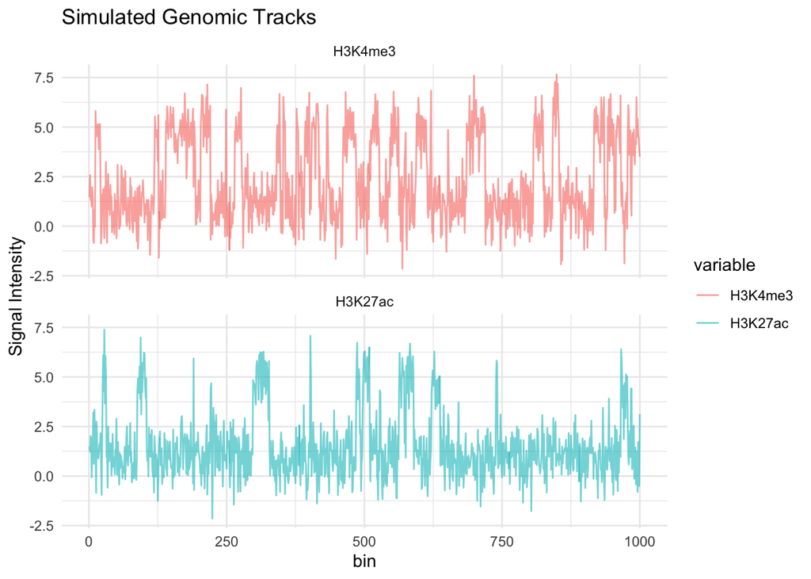

```r
df_melt <- melt(genomic_data, id.vars = c("bin", "TrueState"))

ggplot(df_melt, aes(x = bin, y = value, color = variable)) +
  geom_line(alpha = 0.6) +
  facet_wrap(~variable, ncol = 1) +
  theme_minimal() +
  labs(title = "Simulated Genomic Tracks", y = "Signal Intensity")
```

## Step 3: Fitting the Hidden Markov Model

We use the `depmix` function to define a model with 3 states. We model the emissions as a multi-variate Gaussian (Normal) distribution.

```r
# Define the model:
# We observe H3K4me3 and H3K27ac simultaneously
mod <- depmix(list(H3K4me3 ~ 1, H3K27ac ~ 1),
              data = genomic_data,
              nstates = 3,
              family = list(gaussian(), gaussian()))

# Fit the model using Expectation-Maximization (EM)
fit_mod <- fit(mod)
```

```
## converged at iteration 42 with logLik: -3095.769
```

```r
# Summary of the model parameters (Transition and Emission)
summary(fit_mod)
```

```
## Initial state probabilities model
## pr1 pr2 pr3
##   0   0   1
##
## Transition matrix
##         toS1  toS2  toS3
## fromS1 0.923 0.026 0.052
## fromS2 0.044 0.889 0.067
## fromS3 0.043 0.012 0.944
##
## Response parameters
## Resp 1 : gaussian
## Resp 2 : gaussian
##     Re1.(Intercept) Re1.sd Re2.(Intercept) Re2.sd
## St1           4.942  0.971           0.962  0.986
## St2           1.102  1.064           4.980  0.966
## St3           0.932  1.006           0.974  0.962
```

## Step 4: Decoding the Genome

Now that the model is trained, we use the **Viterbi algorithm** to find the most likely sequence of hidden states that produced our observed signals.

```r
# Predict the states
est_states <- posterior(fit_mod)

# Add predictions back to our dataframe
genomic_data$PredictedState <- as.factor(est_states$state)

# Visualize True vs Predicted
# ggplot(genomic_data, aes(x = bin)) +
#   geom_tile(aes(y = 2, fill = TrueState)) +
#   geom_tile(aes(y = 1, fill = PredictedState)) +
#   scale_y_continuous(breaks = c(1, 2), labels = c("Predicted", "True")) +
#   theme_minimal() +
#   labs(title = "HMM Segmentation Results", x = "Genomic Position", y = "") +
#   scale_fill_brewer(palette = "Set1")
```

### Aligned Genomic Tracks Visualization

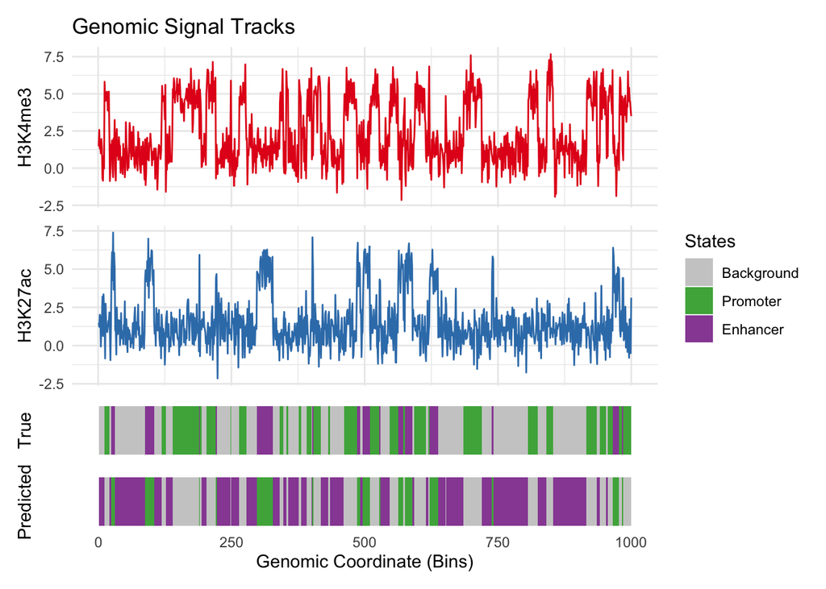

```r
# Load necessary libraries
library(ggplot2)
library(patchwork) # For combining multiple plots
library(dplyr)
library(tidyr)

# 1. Create the Signal Tracks (Line plots)
# We plot the continuous intensity for each histone mark
p1 <- ggplot(genomic_data, aes(x = bin, y = H3K4me3)) +
  geom_line(color = "#e41a1c", size = 0.5) +
  labs(title = "Genomic Signal Tracks", y = "H3K4me3") +
  theme_minimal() +
  theme(axis.text.x = element_blank(), axis.title.x = element_blank())

p2 <- ggplot(genomic_data, aes(x = bin, y = H3K27ac)) +
  geom_line(color = "#377eb8", size = 0.5) +
  labs(y = "H3K27ac") +
  theme_minimal() +
  theme(axis.text.x = element_blank(), axis.title.x = element_blank())

# 2. Create the State Tracks (Heatmap/Ribbon style)
# This shows the True vs Predicted functional categories
p3 <- ggplot(genomic_data, aes(x = bin, y = 1, fill = TrueState)) +
  geom_tile() +
  scale_fill_manual(values = c("1" = "grey80", "2" = "#4daf4a", "3" = "#984ea3"),
                    labels = c("Background", "Promoter", "Enhancer")) +
  labs(y = "True", fill = "States") +
  theme_minimal() +
  theme(axis.text = element_blank(), axis.title.x = element_blank(),
        panel.grid = element_blank())

p4 <- ggplot(genomic_data, aes(x = bin, y = 1, fill = PredictedState)) +
  geom_tile() +
  scale_fill_manual(values = c("1" = "grey80", "2" = "#4daf4a", "3" = "#984ea3")) +
  labs(y = "Predicted", x = "Genomic Coordinate (Bins)") +
  theme_minimal() +
  theme(axis.text.y = element_blank(), panel.grid = element_blank(),
        legend.position = "none")

# 3. Combine the plots using patchwork
# We specify the heights to give more room to the signals
combined_plot <- (p1 / p2 / p3 / p4) +
  plot_layout(heights = c(3, 3, 1, 1), guides = "collect")

print(combined_plot)
```

## Conclusion

The HMM successfully “smoothed” the noisy signal into discrete blocks. While the predicted state numbers (1, 2, 3) might be swapped compared to our simulation (label switching), the **segment boundaries** should align closely with the truth. In a real biological context, you would look at the emission means to determine which state corresponds to a “Promoter” vs an “Enhancer.”